# set2

### 2. Consider the daily closing IBM stock prices (data set ibmclose).

> 1. Produce some plots of the data in order to become familiar with it

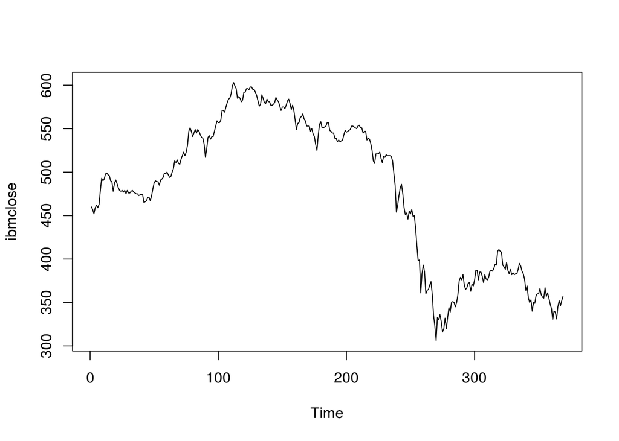

```r
plot(ibmclose)
```

> 2. Split the data into a training set of 300 observations and a test set of 69 observations.

```r
training <- window(ibmclose, end=300)
test <- window(ibmclose, start=301)
```

> 3. Try various benchmark methods to forecast the training set and compare the results on the test set. Which method did best?

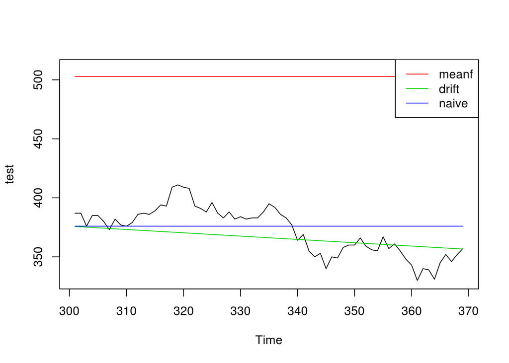

```r
ibmclose_fit1 <- meanf(training, h=69)
ibmclose_fit2 <- rwf(training, h=69, drift=TRUE)
ibmclose_fit3 <- naive(training, h=69)
plot(test, ylim=c(330,510))
lines(ibmclose_fit1$mean, col=2)
lines(ibmclose_fit2$mean, col=3)
lines(ibmclose_fit3$mean, col=4)
legend("topright", lty=1, col=c(2,3,4),
       legend=c("meanf", "drift", "naive"))
```

```r
accuracy(ibmclose_fit1, test)
```

```
##                         ME      RMSE       MAE        MPE     MAPE
## Training set  1.660438e-14  73.61532  58.72231  -2.642058 13.03019
## Test set     -1.306180e+02 132.12557 130.61797 -35.478819 35.47882
##                  MASE      ACF1 Theil's U
## Training set 11.52098 0.9895779        NA
## Test set     25.62649 0.9314689  19.05515
```

```r
accuracy(ibmclose_fit2, test)
```

```
##                        ME      RMSE       MAE         MPE     MAPE
## Training set 2.870480e-14  7.297409  5.127996 -0.02530123 1.121650
## Test set     6.108138e+00 17.066963 13.974747  1.41920066 3.707888
##                  MASE      ACF1 Theil's U
## Training set 1.006083 0.1351052        NA
## Test set     2.741765 0.9045875  2.361092
```

```r
accuracy(ibmclose_fit3, test)
```

```
##                      ME      RMSE      MAE         MPE     MAPE     MASE
## Training set -0.2809365  7.302815  5.09699 -0.08262872 1.115844 1.000000
## Test set     -3.7246377 20.248099 17.02899 -1.29391743 4.668186 3.340989
##                   ACF1 Theil's U
## Training set 0.1351052        NA
## Test set     0.9314689  2.973486
```

> 4. For the best method, compute the residuals and plot them. What do the plots tell you?

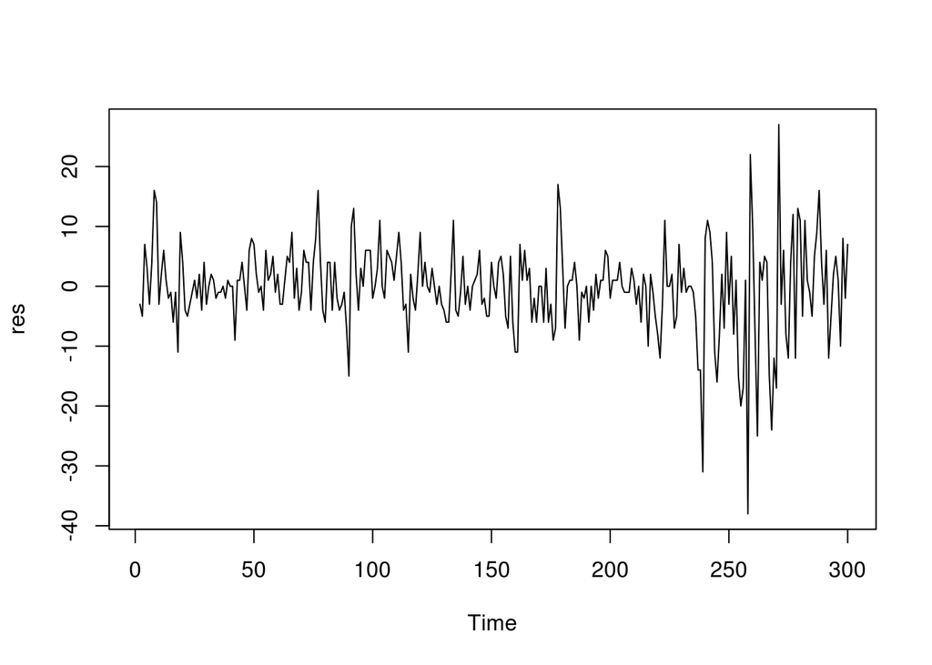

```r
res <- residuals(ibmclose_fit3)
plot(res)
```

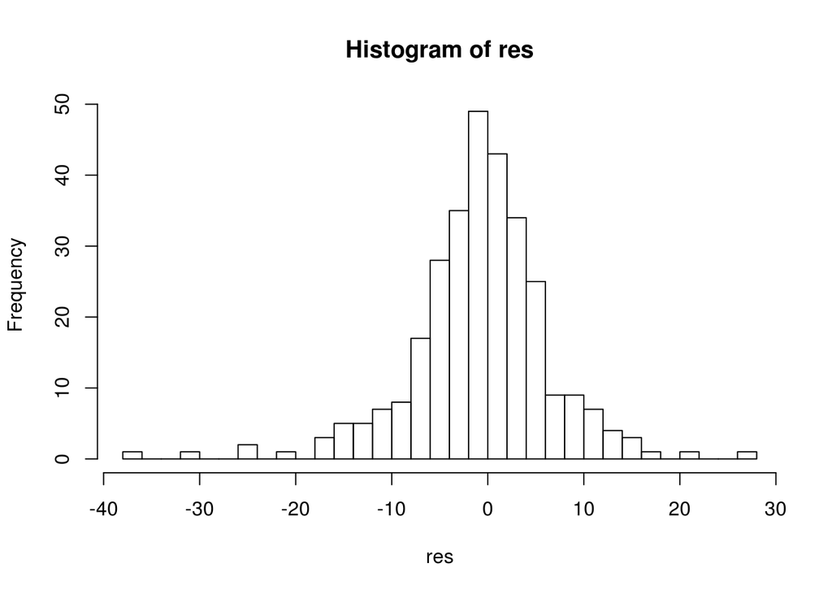

```r
hist(res, breaks="FD")
```

```r
shapiro.test(res)
```

```
##
##  Shapiro-Wilk normality test
##
## data:  res
## W = 0.94174, p-value = 1.77e-09
```

Temos ausência de normalidade pelo teste de shapiro (p-value < 0.05).

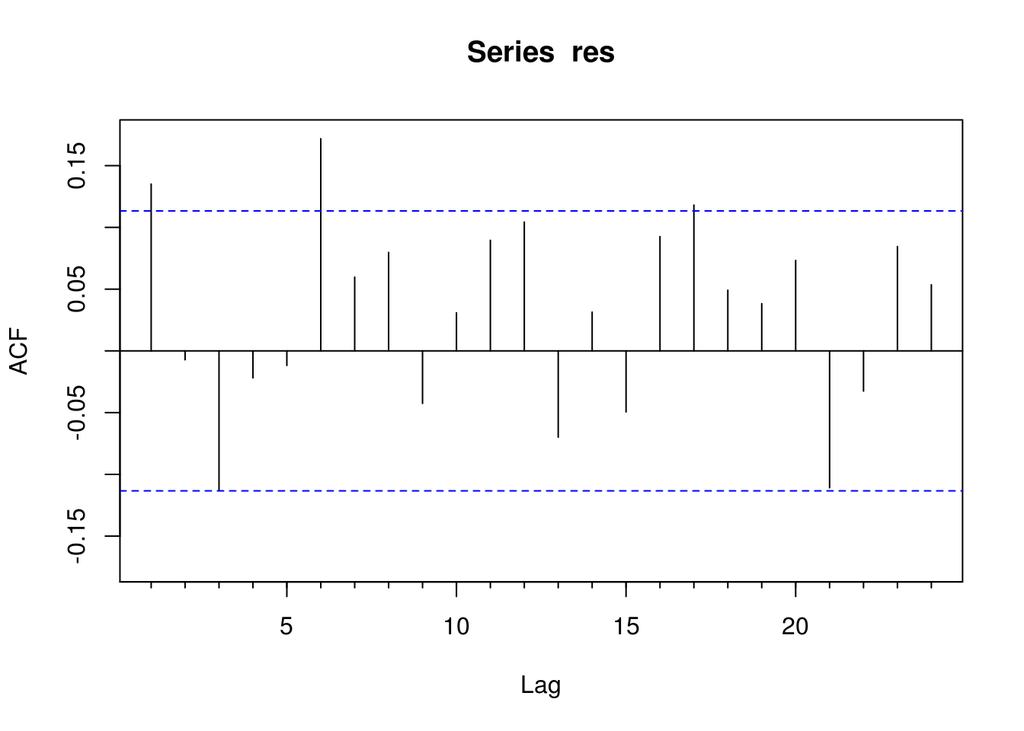

```r
Acf(res)
```

```r
Box.test(res, type="Lj")
```

```
##
##  Box-Ljung test
##
## data:  res
## X-squared = 5.5127, df = 1, p-value = 0.01888
```

E os dados não são white-noise (p-value < 0.05)

### 3. Consider the sales of new one-family houses in the USA (Jan 1987 – Nov 1995). Data set: hsales

> 1. Produce some plots of the data in order to become familiar with it

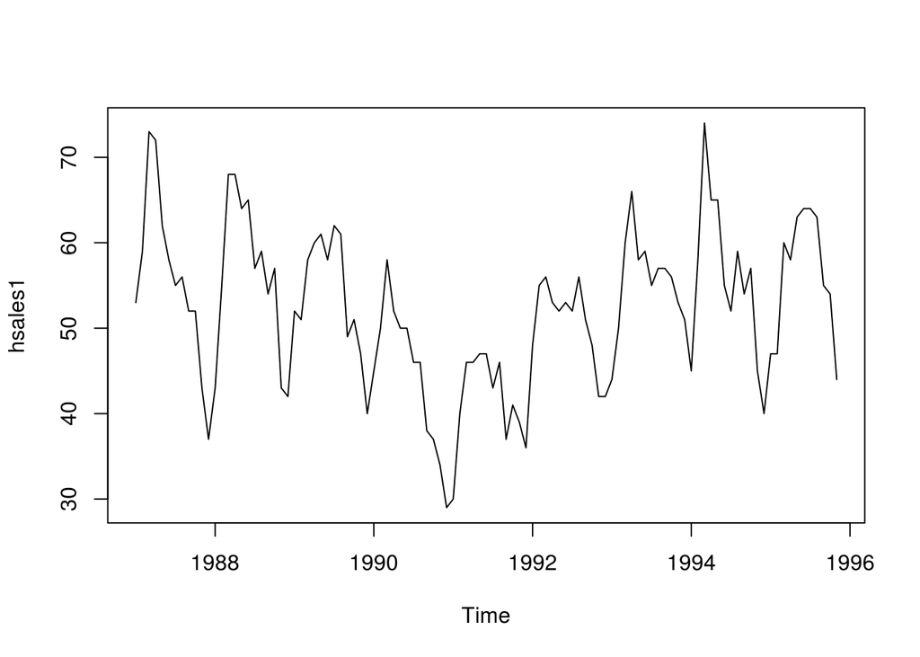

```r
hsales1 <- window(hsales, start=c(1987,1))
plot(hsales1)
```

> 2. Split the data into a training set and a test set, where the test set is the last two years of data

```r
test <- window(hsales1, start=c(1994))
training <- window(hsales1, end=c(1993, 12))
```

> 3. Try various benchmark methods to forecast the training set and compare the results on the test set. Which method did best?

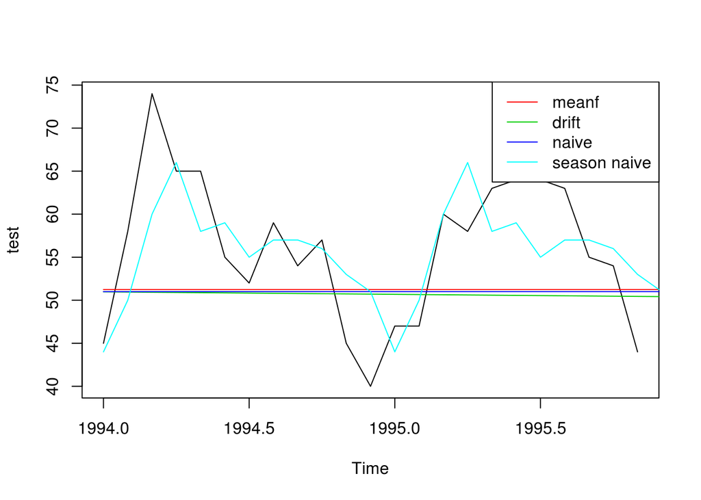

```r
training_fit1 <- meanf(training, h=7*12)
training_fit2 <- rwf(training, h=7*12, drift=TRUE)
training_fit3 <- naive(training, h=7*12)
training_fit4 <- snaive(training, h=7*12)
plot(test)
lines(training_fit1$mean, col=2)
lines(training_fit2$mean, col=3)
lines(training_fit3$mean, col=4)
lines(training_fit4$mean, col=5)
legend("topright", lty=1, col=c(2,3,4,5),
       legend=c("meanf", "drift", "naive", "season naive"))
```

```r
accuracy(training_fit1, test)
```

```
##                         ME     RMSE      MAE       MPE     MAPE     MASE
## Training set -2.707402e-15 9.085073 7.250567 -3.523272 15.28814 1.078597
## Test set      4.761905e+00 9.549737 8.190476  6.372948 14.22554 1.218418
##                   ACF1 Theil's U
## Training set 0.8079425        NA
## Test set     0.5095178  1.166451
```

```r
accuracy(training_fit2, test)
```

```
##                         ME     RMSE      MAE        MPE      MAPE
## Training set -3.167395e-15 5.661061 4.338220 -0.6535756  8.740181
## Test set      5.289157e+00 9.809644 8.438449  7.3401571 14.565177
##                   MASE      ACF1 Theil's U
## Training set 0.6453551 0.1544595        NA
## Test set     1.2553065 0.5077287  1.193363
```

```r
accuracy(training_fit3, test)
```

```
##                       ME     RMSE      MAE        MPE      MAPE      MASE
## Training set -0.02409639 5.661112 4.337349 -0.7022996  8.740746 0.6452255
## Test set      5.00000000 9.670664 8.304348  6.8080182 14.381673 1.2353575
##                   ACF1 Theil's U
## Training set 0.1544595        NA
## Test set     0.5095178  1.179633
```

```r
accuracy(training_fit4, test)
```

```
##                       ME     RMSE      MAE        MPE     MAPE      MASE
## Training set -0.08333333 7.954733 6.722222 -1.4490906 14.19222 1.0000000
## Test set      0.30434783 6.160886 5.000000 -0.7312374  9.12828 0.7438017
##                   ACF1 Theil's U
## Training set 0.7831361        NA
## Test set     0.2243070 0.8031005
```

O método seasonal naive é o melhor.

> 4. For the best method, compute the residuals and plot them. What do the plots tell you?

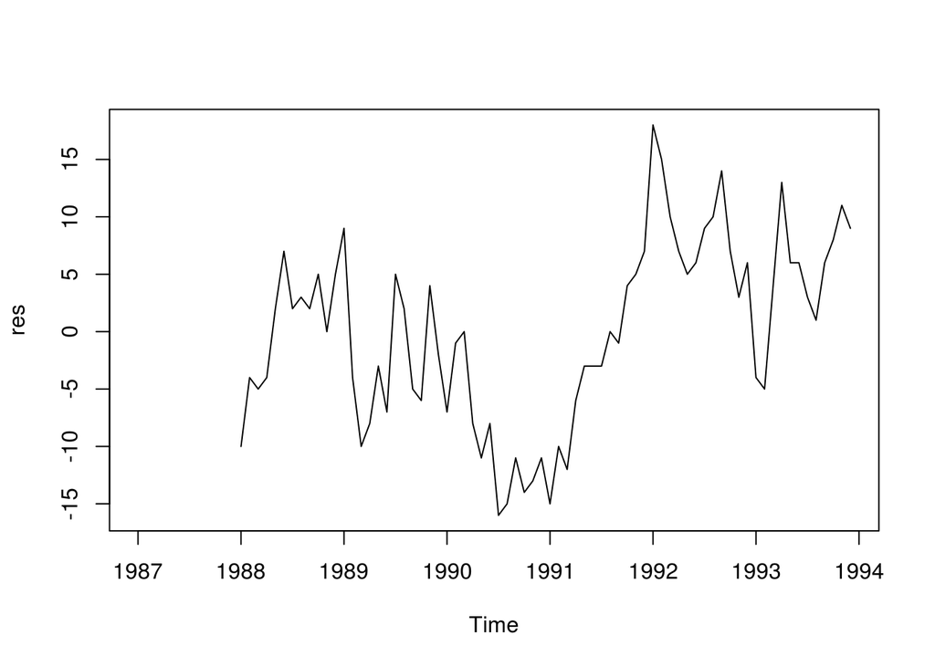

```r
res <- residuals(training_fit4)
plot(res)
```

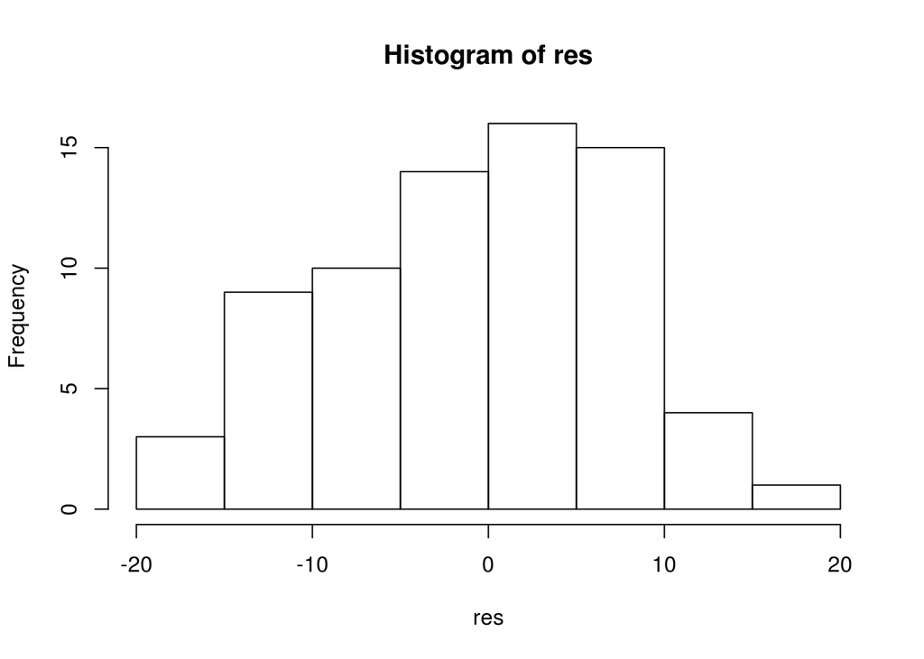

```r
hist(res, breaks="FD")
```

```r
shapiro.test(res)
```

```
##
##  Shapiro-Wilk normality test
##
## data:  res
## W = 0.98008, p-value = 0.3108
```

```r
Box.test(res, type="Lj")
```

```
##
##  Box-Ljung test
##
## data:  res
## X-squared = 46.024, df = 1, p-value = 1.168e-11
```

Os dados não pertencem a white-noise [[porém o método pareceu bom?]]